# ResMod Results

# Aim 1: relationship between victimization type and PTSS severity

Victimization = CSA only, ASA (adolescent or adult) only, CSA + ASA

PTSS severity = PCL-5 score (0-80)

Negative binomial regression results:

Coefficients Table for Aim 1

|  | Estimate | Std. Error | z value | Pr(>\|z\|) |
| --- | --- | --- | --- | --- |
| (Intercept) | 2.662 | 0.092 | 29.048 | 0.000 |
| vicASA_only | 0.328 | 0.133 | 2.462 | 0.014 |
| vicCSA_ASA | 0.652 | 0.146 | 4.470 | 0.000 |

95% confidence intervals:

|  | 2.5 % | 97.5 % |
| --- | --- | --- |
| (Intercept) | 2.486 | 2.846 |
| vicASA_only | 0.067 | 0.590 |
| vicCSA_ASA | 0.369 | 0.942 |

Pairwise comparisons:

| contrast | estimate | SE | df | z.ratio | p.value |
| --- | --- | --- | --- | --- | --- |
| CSA_only - ASA_only | -0.328 | 0.133 | Inf | -2.462 | 0.037 |
| CSA_only - CSA_ASA | -0.652 | 0.146 | Inf | -4.470 | 0.000 |
| ASA_only - CSA_ASA | -0.324 | 0.149 | Inf | -2.174 | 0.076 |

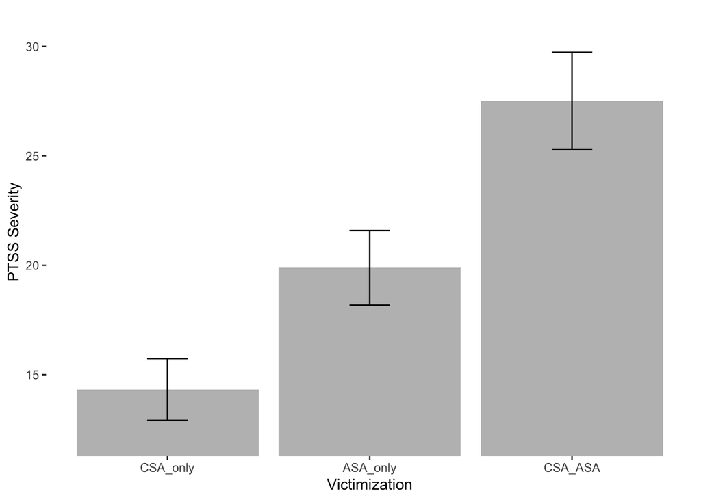

> *Summary:*
> 1. Experiencing ASA only (compared to experiencing CSA only) is associated with a 38.8% increase in PTSS severity.
> 2. Experiencing revictimization (compared to CSA only) is associated with a 91.9% increase in PTSS severity while experiencing revictimization (compared to ASA only) is associated with a 38.3% increase in PTSS severity.

# Aim 2: moderation analyses of resilience variables

## Aim 2a: Emotion regulation

Emotion regulation: reverse scoring of Difficulties in Emotion Regulation Strategies

Negative binomial regression results:

Coefficients Table for Aim 2a

|  | Estimate | Std. Error | z value | Pr(>\|z\|) |
| --- | --- | --- | --- | --- |
| (Intercept) | 2.674 | 0.087 | 30.580 | 0.000 |
| vicASA_only | 0.275 | 0.126 | 2.173 | 0.030 |
| vicCSA_ASA | 0.552 | 0.140 | 3.928 | 0.000 |
| mcERS | -0.014 | 0.005 | -2.859 | 0.004 |
| vicASA_only:mcERS | -0.006 | 0.007 | -0.837 | 0.403 |
| vicCSA_ASA:mcERS | 0.004 | 0.007 | 0.557 | 0.578 |

95% confidence intervals:

|  | 2.5 % | 97.5 % |
| --- | --- | --- |
| (Intercept) | 2.507 | 2.850 |
| vicASA_only | 0.027 | 0.523 |
| vicCSA_ASA | 0.279 | 0.830 |
| mcERS | -0.024 | -0.005 |
| vicASA_only:mcERS | -0.020 | 0.008 |
| vicCSA_ASA:mcERS | -0.009 | 0.017 |

Moderation plot:

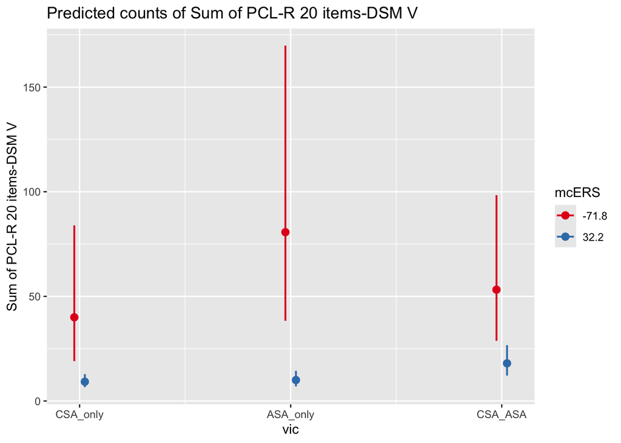

Pairwise comparisons:

| contrast | estimate | SE | df | z.ratio | p.value |
| --- | --- | --- | --- | --- | --- |
| CSA_only - ASA_only | -0.275 | 0.126 | Inf | -2.180 | 0.075 |
| CSA_only - CSA_ASA | -0.532 | 0.140 | Inf | -3.795 | 0.000 |
| ASA_only - CSA_ASA | -0.256 | 0.142 | Inf | -1.804 | 0.168 |

## Aim 2b: Mindfulness

Mindfulness: Southampton Mindfulness Questionnaire

Negative binomial regression results:

Coefficients Table for Aim 2b

|  | Estimate | Std. Error | z value | Pr(>\|z\|) |
| --- | --- | --- | --- | --- |
| (Intercept) | 2.682 | 0.092 | 29.016 | 0.000 |
| vicASA_only | 0.224 | 0.134 | 1.680 | 0.093 |
| vicCSA_ASA | 0.621 | 0.145 | 4.296 | 0.000 |
| mcSMQ | -0.008 | 0.008 | -1.041 | 0.298 |
| vicASA_only:mcSMQ | -0.011 | 0.010 | -1.063 | 0.288 |
| vicCSA_ASA:mcSMQ | 0.001 | 0.011 | 0.080 | 0.936 |

95% confidence intervals:

|  | 2.5 % | 97.5 % |
| --- | --- | --- |
| (Intercept) | 2.506 | 2.867 |
| vicASA_only | -0.037 | 0.486 |
| vicCSA_ASA | 0.340 | 0.906 |
| mcSMQ | -0.022 | 0.006 |
| vicASA_only:mcSMQ | -0.029 | 0.008 |
| vicCSA_ASA:mcSMQ | -0.019 | 0.021 |

Moderation plot:

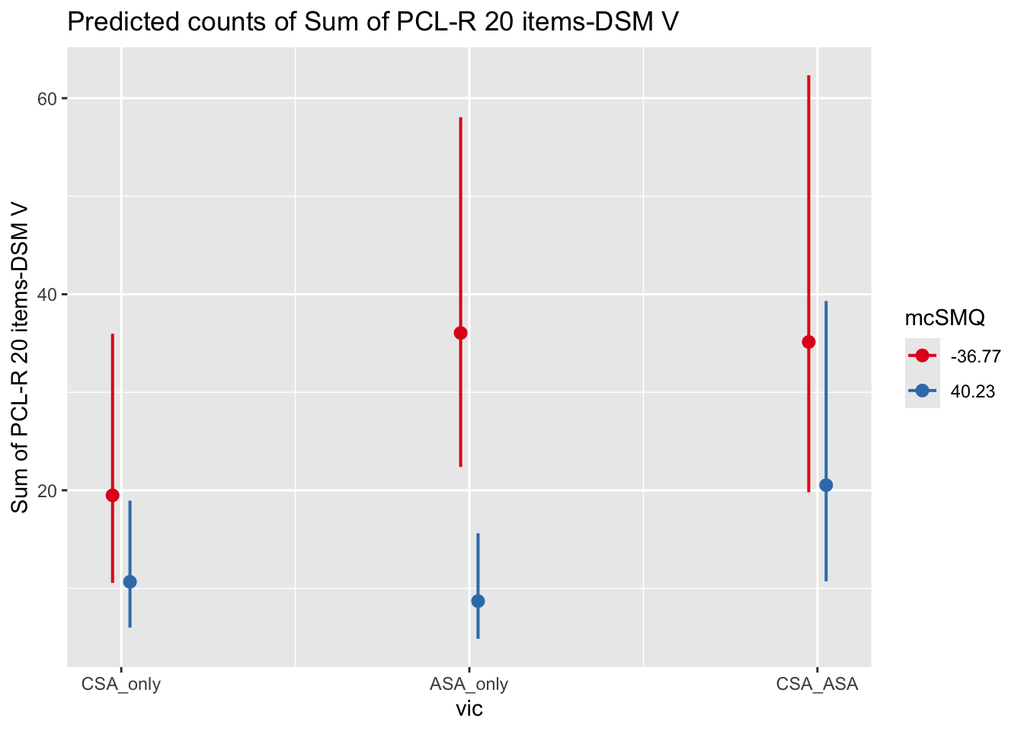

> *Summary:*
> 1. There was no interactive effect between mindfulness and victimization on PTSS, meaning the effect of mindfulness does not differ based on the type of victimization experienced.
> 2. There was also no main effect of mindfulness on PTSS severity, meaning mindfulness does not have a significant effect on PTSS severity.

# Aim 3: cumulative resilience

3-way interaction between victimization, emotion regulation, and mindfulness

Negative binomial regression results:

Coefficients Table for Aim 3

|  | Estimate | Std. Error | z value | Pr(>\|z\|) |
| --- | --- | --- | --- | --- |
| (Intercept) | 2.698 | 0.093 | 28.939 | 0.000 |
| vicASA_only | 0.225 | 0.139 | 1.616 | 0.106 |
| vicCSA_ASA | 0.566 | 0.155 | 3.654 | 0.000 |
| mcERS | -0.014 | 0.005 | -2.579 | 0.010 |
| mcSMQ | 0.000 | 0.008 | 0.014 | 0.989 |
| vicASA_only:mcERS | -0.002 | 0.008 | -0.302 | 0.762 |
| vicCSA_ASA:mcERS | 0.002 | 0.007 | 0.329 | 0.742 |
| vicASA_only:mcSMQ | -0.011 | 0.011 | -1.015 | 0.310 |
| vicCSA_ASA:mcSMQ | 0.000 | 0.012 | -0.004 | 0.997 |
| mcERS:mcSMQ | 0.000 | 0.000 | -0.745 | 0.456 |
| vicASA_only:mcERS:mcSMQ | 0.000 | 0.001 | 0.239 | 0.811 |
| vicCSA_ASA:mcERS:mcSMQ | 0.000 | 0.001 | 0.057 | 0.954 |

95% confidence intervals:

|  | 2.5 % | 97.5 % |
| --- | --- | --- |
| (Intercept) | 2.5211740 | 2.8840921 |
| vicASA_only | -0.0444408 | 0.4969279 |
| vicCSA_ASA | 0.2688471 | 0.8708568 |
| mcERS | -0.0241346 | -0.0037708 |
| mcSMQ | -0.0142038 | 0.0144104 |
| vicASA_only:mcERS | -0.0176618 | 0.0127574 |
| vicCSA_ASA:mcERS | -0.0119829 | 0.0167820 |
| vicASA_only:mcSMQ | -0.0301487 | 0.0082731 |
| vicCSA_ASA:mcSMQ | -0.0210883 | 0.0208051 |
| mcERS:mcSMQ | -0.0010211 | 0.0004701 |
| vicASA_only:mcERS:mcSMQ | -0.0008879 | 0.0011428 |
| vicCSA_ASA:mcERS:mcSMQ | -0.0009953 | 0.0010553 |

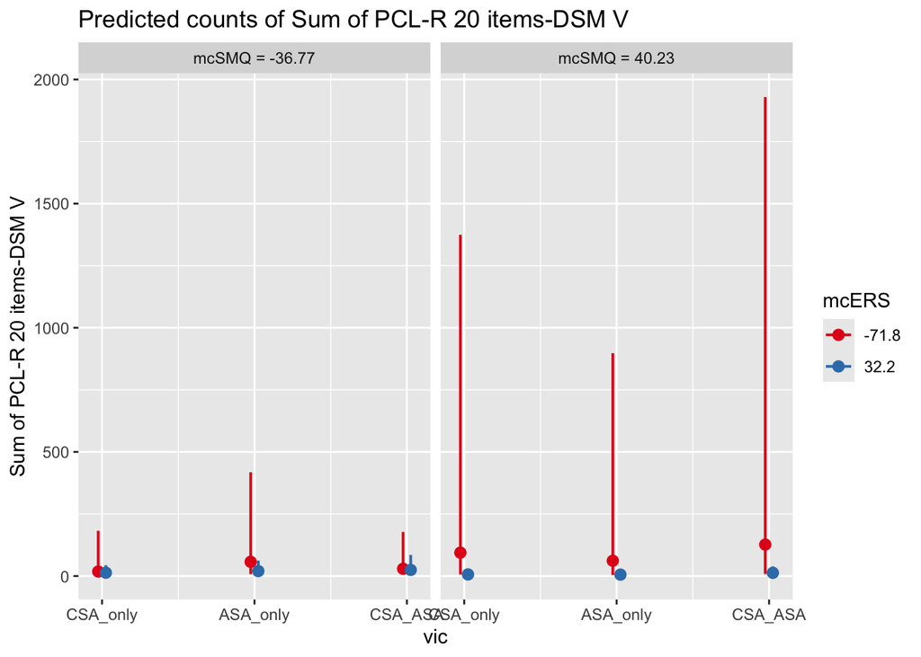

Main effects only:

Coefficients Table for Aim 3 Main Effects

|  | Estimate | Std. Error | z value | Pr(>\|z\|) |
| --- | --- | --- | --- | --- |
| (Intercept) | 2.687 | 0.087 | 30.768 | 0.000 |
| vicASA_only | 0.239 | 0.128 | 1.874 | 0.061 |
| vicCSA_ASA | 0.525 | 0.140 | 3.756 | 0.000 |
| mcERS | -0.013 | 0.003 | -4.148 | 0.000 |
| mcSMQ | -0.005 | 0.004 | -1.158 | 0.247 |

| contrast | estimate | SE | df | z.ratio | p.value |
| --- | --- | --- | --- | --- | --- |
| CSA_only - ASA_only | -0.239 | 0.128 | Inf | -1.874 | 0.146 |
| CSA_only - CSA_ASA | -0.525 | 0.140 | Inf | -3.756 | 0.001 |
| ASA_only - CSA_ASA | -0.285 | 0.143 | Inf | -2.001 | 0.112 |

> *Summary:*
> 1. There was no interactive effect for cumulative resilience (emotion regulation + mindfulness), meaning the effect of these resilience factors does not differ by victimization type.
> 2. There was a significant main effect for emotion regulation, such that with a one-unit increase in emotion regulation, there was a 1.3% decrease in PTSS severity, holding all else constant.
> 3. When controlling for emotion regulation and mindfulness, there remain significant differences in PTSS severity between CSA only and CSA + ASA. Specifically, individuals who experienced CSA + ASA reported 69.0% greater PTSS severity compared to individuals experiencing CSA only, holding resilience factors constant.